# Bed-1304 Python lab

Seminar 7 - Matplotlib og visualisering

## Last ned seminaroppgavene

Gå inn på canvas eller uit-bed-1304-h25.github.io og finn “Oppgaver”

Last ned “Seminar7.1_Matplotlib.ipynb”

Vi starter med datainnlasting og installasjon av matplotlib

### Installere matplotlib

Om du ikke har matplotlib installert:

```python
# %pip install matplotlib
```

## Laste inn datasett

Først må vi laste inn pandas for å kunne laste inn datasettet vi skal bruke

Datasettet ligger på canvas under “Ressurser” -> “Data til forelesningsnotater”

Klikk på StudentPerformanceFactors.csv, så last ned og legg filen i samme mappe som Seminar7.1_Matplotlib.ipynb

```python
import pandas as pd
df = pd.read_csv("StudentPerformanceFactors.csv") # Last inn datasettet
```

Evt kan du trykke på “Raw” og kopiere linken til filen direkte fra github.

```python
df = pd.read_csv("https://raw.githubusercontent.com/uit-bed-1304-h25/uit-bed-1304-h25.github.io/refs/heads/main/data/StudentPerformanceFactors.csv")
```

## Oppgave 1a

Lag et scatter-plot som viser forholdet mellom antall timer brukt på å studere (`Hours_Studied`) og eksamensresultatet (`Exam_Score`). Bruk en farge for å indikere kjønn (`Gender`) i plottet, hvor for eksempel blå representerer “Male” og rød representerer “Female”.

Hva kan vi si om sammenhengen mellom antall timer studert og eksamensresultater? Ser det ut til å være en forskjell mellom kjønnene?

## Eksempel på plotting med matplotlib

```python
# Importer matplotlib først
import matplotlib.pyplot as plt
df = pd.read_csv("StudentPerformanceFactors.csv")

fargevariabel = df['Gender'].map({'Male': 'blue', 'Female': 'red'})
# Eksempel på enkel plotting
plt.figure(figsize=(10, 6))
plt.scatter(df['variabel x'], df['variabel y'], color=fargevariabel, alpha=0.7)

# Tittel og akse-navn
plt.title('Studietimer vs Eksamensresultater etter kjønn')
plt.xlabel('Antall timer studert per uke')
plt.ylabel('Eksamensresultat')

# Legg til en legende og vis plottet
plt.legend()
plt.show()
```

## Oppave 1a figur

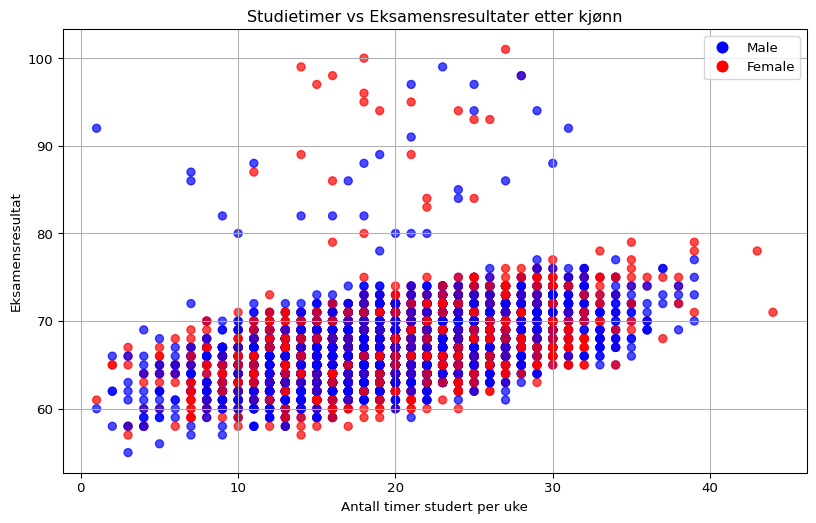

## Oppgave 1a Fra løsningsforslag

```python
import pandas as pd
import matplotlib.pyplot as plt
df = pd.read_csv("https://raw.githubusercontent.com/uit-bed-1304-h25/uit-bed-1304-h25.github.io/refs/heads/main/data/StudentPerformanceFactors.csv")


colors = df['Gender'].map({'Male': 'blue', 'Female': 'red'}) # Lag farger basert på kjønn
plt.figure(figsize=(10, 6)) # Scatter-plot av antall timer studert vs. eksamensresultat
plt.scatter(df['Hours_Studied'], df['Exam_Score'], c=colors, alpha=0.7)
 # Tittel og akse-navn
plt.title('Studietimer vs Eksamensresultater etter kjønn')
plt.xlabel('Antall timer studert per uke')
plt.ylabel('Eksamensresultat')

# Legg til en legend
plt.legend(handles=[plt.Line2D([0], [0], marker='o', color='w', markerfacecolor='blue', markersize=10, label='Male'),
                    plt.Line2D([0], [0], marker='o', color='w', markerfacecolor='red', markersize=10, label='Female')])
# Vise plottet
plt.grid(True)
plt.show()
```

## LF kode som jeg ville gjort det

```python
import matplotlib.pyplot as plt
import pandas as pd
df = pd.read_csv("https://raw.githubusercontent.com/uit-bed-1304-h25/uit-bed-1304-h25.github.io/refs/heads/main/data/StudentPerformanceFactors.csv")

plt.figure(figsize=(10,6))
plt.scatter(df[df['Gender']=='Male']['Hours_Studied'], df[df['Gender']=='Male']['Exam_Score'], color='blue', alpha=0.7, label='Male')
plt.scatter(df[df['Gender']=='Female']['Hours_Studied'], df[df['Gender']=='Female']['Exam_Score'], color='red', alpha=0.7, label='Female')
plt.xlabel('Hours Studied')
plt.ylabel('Exam Score')
plt.legend()
plt.show()
```

## Oppgave 1b

Lag et histogram som viser fordelingen av antall timer søvn per natt (`Sleep_Hours`). Del dataene inn i intervaller på én time.

Hva er gjennomsnittlig antall timer med søvn per natt blant studentene? Virker det som om søvnmengden har en innvirkning på eksamensresultatene?

## Oppgave 1b LF

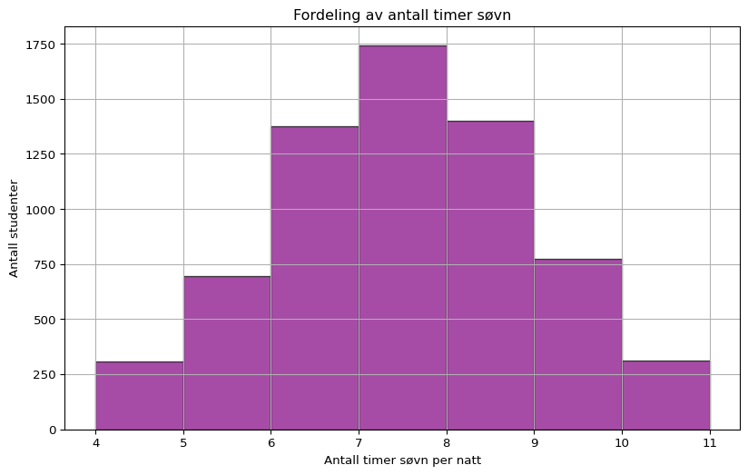

## Oppgave 1b Kode

```python
# Histogram av antall timer søvn
plt.figure(figsize=(10, 6))
plt.hist(df['Sleep_Hours'], bins=range(4, 12), color='purple', edgecolor='black', alpha=0.7)

# Tittel og akse-navn
plt.title('Fordeling av antall timer søvn')
plt.xlabel('Antall timer søvn per natt')
plt.ylabel('Antall studenter')

plt.grid(True)
plt.show()
```

## Oppgave 1c:

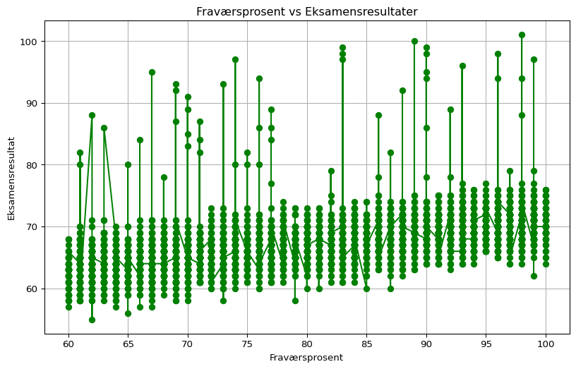

## Oppgave 1c kode

```python
# Sortere data etter fraværsprosent
df_sorted = df.sort_values('Attendance')

# Linjediagram
plt.figure(figsize=(10, 6))
plt.plot(df_sorted['Attendance'], df_sorted['Exam_Score'], color='green', marker='o')

# Tittel og akse-navn
plt.title('Fraværsprosent vs Eksamensresultater')
plt.xlabel('Fraværsprosent')
plt.ylabel('Eksamensresultat')

plt.grid(True)
plt.show()
```

## Oppgave 1d:

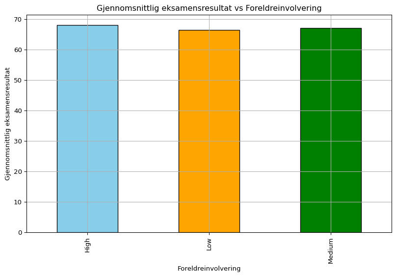

## Oppgave 1d kode

```python
# Beregn gjennomsnittlig eksamensresultat for hver kategori av foreldreinvolvering
avg_scores_by_involvement = df.groupby('Parental_Involvement')['Exam_Score'].mean()

# Bar-plot av gjennomsnittlige eksamensresultater for hver kategori
plt.figure(figsize=(10, 6))
avg_scores_by_involvement.plot(kind='bar', color=['skyblue', 'orange', 'green'], edgecolor='black')

# Tittel og akse-navn
plt.title('Gjennomsnittlig eksamensresultat vs Foreldreinvolvering')
plt.xlabel('Foreldreinvolvering')
plt.ylabel('Gjennomsnittlig eksamensresultat')

plt.grid(True)
plt.show()
```

## Oppgave 1e:

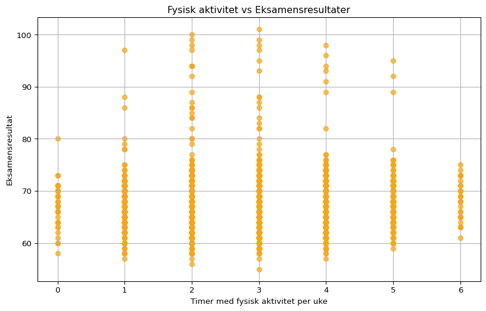

## Oppgave 1e kode

```python
# Scatter-plot av fysisk aktivitet vs eksamensresultater
plt.figure(figsize=(10, 6))
plt.scatter(df['Physical_Activity'], df['Exam_Score'], color='orange', alpha=0.7)

# Tittel og akse-navn
plt.title('Fysisk aktivitet vs Eksamensresultater')
plt.xlabel('Timer med fysisk aktivitet per uke')
plt.ylabel('Eksamensresultat')

plt.grid(True)
plt.show()
```